# Apresentação

## Análise dos dados da Liga Nacional de Basquete Americano

Source: https://www.nba.com/stats/

Glossary: https://www.nba.com/stats/help/glossary/

## Instalação de pacotes

```r
#install.packages("magrittr")
#install.packages("tidyverse")
#install.packages("readxl")
#install.packages("kableExtra")
#install.packages("summarytools")
#install.packages("knitr")
#install.packages("sf")
#install.packages("ggplot2")
#install.packages("RColorBrewer")
#install.packages("ggspatial")
#install.packages("ggcorrplot")
#install.packages("Hmisc")
```

## Import das bibliotecas

```r
library(sf)           #Para lidar com dados espaciais
library(dplyr)        #Para manipulação de dados
```

```r
library(ggplot2)      #Para visualização de dados
library(RColorBrewer) #Para acessar paleta de cores
library(ggspatial)    #Para adicionar elementos de mapas
library(knitr)
library(magrittr)
library(tidyverse)
library(readxl)
library(kableExtra)
library(summarytools)
library(ggcorrplot) #montar gráficos da matriz de correlação\
library(Hmisc) #montar matriz de correlação
library(car)
```

## Importar os dados

- Games: Informações jogo a jogo de cada temporada com todas as características gerais da partida.
- Games Details: Tabela de informações mais detalhadas de cada jogo, demonstrando estatisticas jogador a jogador.
- Players: Tabela com informações de jogadores por time de cada temporada.
- Ranking: Acompanhamento do ranking semana a semana ao longo das temporadas.
- Teams: Tabela geral de informações de time a time.
- Usa States: Mapa dos Estados Unidos
- NBA Titles: Títulos dos Times

```r
games <- read_csv("dataset/games.csv")
games_details <- read_csv("dataset/games_details.csv")
players <- read_csv("dataset/players.csv")
ranking <- read_csv("dataset/ranking.csv")
teams <- read_csv("dataset/teams.csv")
usa_states <- "dataset/estados_USAt.shp"
nba_titles <- "dataset/est_tit.csv"
```

## Glossário

### Tabela - Games:

- GAME_DATE_EST: Game’s date
- GAME_ID: ID of the game
- GAME_STATUS_TEXT: Status final means that the game is completed
- HOME_TEAM_ID: ID of the home team
- VISITOR_TEAM_ID: ID of the visitor team
- SEASON: Season when the game occured
- TEAM_ID_home: ID of the home team (dupplicate of HOME_TEAM_ID)
- PTS_home: Number of points scored by home team
- FG_PCT_home: Field Goal Percentage home team
- FT_PCT_home: Free Throw Percentage of the home team
- FG3_PCT_home: Three Point Percentageof the home team
- AST_home: Assists of the home team
- REB_home: Rebounds of the home team
- TEAM_ID_away: ID of the away team (dupplicate of VISITOR_TEAM_ID)
- PTS_away: Number of points scored by away team
- FG_PCT_away: Field Goal Percentage away team
- FT_PCT_away: Free Throw Percentage of the away team
- FG3_PCT_away: Three Point Percentage of the away team
- AST_away: Assists of the away team
- REB_away: Rebounds of the away team
- HOME_TEAM_WINS: If home team won the game

### Tabela - Games_details

- GAME_ID: ID of the game
- TEAM_ID: ID of the team
- TEAM_ABBREVIATION: Team’s abbreviation
- TEAM_CITY: City where the game was played
- PLAYER_ID: ID of the player
- PLAYER_NAME: Player’s name
- START_POSITION: Position of the player (if nothing then he’s on the bench)
- COMMENT: Comment
- MIN: Minutes played
- FGM: Field Goals Made
- FGA: Field Goals Attempted
- FG_PCT: Field Goal Percentage
- FG3M: Three Pointers Made
- FG3A: Three Pointers Attempted
- FG3_PCT: Three Point Percentage
- FTM: Free Throws Made
- FTA: Free Throws Attempted
- FT_PCT: Free Throw Percentage
- OREB: Offensive Rebounds
- DREB: Defensive Rebounds
- REB: Rebounds
- AST: Assists
- STL: Steals
- BLK: Blocked shots
- TO: Turnovers
- PF: Personnal Foul
- PTS: Number of points scored by the player
- PLUS_MINUS: Plus - Minus

### Tabela - players

- PLAYER_NAME: Player’s name
- TEAM_ID: ID of the team
- PLAYER_ID: ID of the player
- SEASON: Season

### Tabela - ranking

- TEAM_ID: ID of the team
- LEAGUE_ID: ID of the league (here only NBA)
- SEASON_ID: Season
- STANDINGSDATE: Standings date
- CONFERENCE: Conference (west or east)
- TEAM: Team name
- G: Number of games played on the season
- W: Number of winning games on the season
- L: Number of loosing games on the season
- W_PCT: Win %
- HOME_RECORD: Home record on the season
- ROAD_RECORD: Road record on the season
- RETURNTOPLAY(empty column)

### Tabela - teams

- LEAGUE_ID: ID of the league (here only NBA)
- TEAM_ID: ID of the team
- MIN_YEAR: Minimum year of the team into NBA championship
- MAX_YEAR: Maximum year of the team into NBA championship
- ABBREVIATION: Abbreviation of team name
- NICKNAME: Team’s nickname
- YEARFOUNDED: Founded Year
- CITY: Team’s city
- ARENA: Team’s stadium
- ARENACAPACITY: Capacity of the stadium
- OWNER: Owner of the team (last one)
- GENERALMANAGER: General manager
- HEADCOACH: Head coach
- DLEAGUEAFFILIATION: League Affiliation

## Verificando tabelas

```r
glimpse(games)
```

```
## Rows: 24,195
## Columns: 21
## $ GAME_DATE_EST    <date> 2021-03-21, 2021-03-21, 2021-03-21, 2021-03-21, 2021~
## $ GAME_ID          <dbl> 22000645, 22000016, 22000646, 22000167, 22000647, 220~
## $ GAME_STATUS_TEXT <chr> "Final", "Final", "Final", "Final", "Final", "Final",~
## $ HOME_TEAM_ID     <dbl> 1610612748, 1610612745, 1610612743, 1610612738, 16106~
## $ VISITOR_TEAM_ID  <dbl> 1610612754, 1610612760, 1610612740, 1610612753, 16106~
## $ SEASON           <dbl> 2020, 2020, 2020, 2020, 2020, 2020, 2020, 2020, 2020,~
## $ TEAM_ID_home     <dbl> 1610612748, 1610612745, 1610612743, 1610612738, 16106~
## $ PTS_home         <dbl> 106, 112, 108, 112, 113, 116, 86, 100, 111, 92, 94, 1~
## $ FG_PCT_home      <dbl> 0.402, 0.494, 0.500, 0.455, 0.489, 0.506, 0.390, 0.43~
## $ FT_PCT_home      <dbl> 0.826, 0.741, 0.800, 1.000, 0.727, 0.750, 0.720, 0.56~
## $ FG3_PCT_home     <dbl> 0.243, 0.368, 0.353, 0.426, 0.310, 0.515, 0.160, 0.45~
## $ AST_home         <dbl> 27, 22, 30, 27, 24, 29, 20, 16, 30, 17, 18, 24, 25, 2~
## $ REB_home         <dbl> 51, 38, 37, 45, 35, 54, 37, 44, 51, 33, 52, 51, 60, 4~
## $ TEAM_ID_away     <dbl> 1610612754, 1610612760, 1610612740, 1610612753, 16106~
## $ PTS_away         <dbl> 109, 114, 113, 96, 106, 105, 100, 101, 94, 132, 99, 1~
## $ FG_PCT_away      <dbl> 0.388, 0.462, 0.482, 0.381, 0.532, 0.389, 0.463, 0.46~
## $ FT_PCT_away      <dbl> 0.900, 0.680, 0.767, 0.700, 0.789, 0.842, 0.857, 0.60~
## $ FG3_PCT_away     <dbl> 0.333, 0.333, 0.286, 0.324, 0.333, 0.326, 0.500, 0.44~
## $ AST_away         <dbl> 27, 22, 26, 20, 24, 19, 26, 19, 20, 23, 26, 28, 23, 2~
## $ REB_away         <dbl> 50, 52, 45, 44, 43, 37, 52, 44, 41, 52, 49, 34, 46, 4~
## $ HOME_TEAM_WINS   <dbl> 0, 0, 0, 1, 1, 1, 0, 0, 1, 0, 0, 1, 1, 1, 1, 0, 0, 0,~
```

```r
head(games)
```

```
## # A tibble: 6 x 21
##   GAME_DATE_EST  GAME_ID GAME_STATUS_TEXT HOME_TEAM_ID VISITOR_TEAM_ID SEASON
##   <date>           <dbl> <chr>                   <dbl>           <dbl>  <dbl>
## 1 2021-03-21    22000645 Final              1610612748      1610612754   2020
## 2 2021-03-21    22000016 Final              1610612745      1610612760   2020
## 3 2021-03-21    22000646 Final              1610612743      1610612740   2020
## 4 2021-03-21    22000167 Final              1610612738      1610612753   2020
## 5 2021-03-21    22000647 Final              1610612751      1610612764   2020
## 6 2021-03-21    22000648 Final              1610612739      1610612761   2020
## # ... with 15 more variables: TEAM_ID_home <dbl>, PTS_home <dbl>,
## #   FG_PCT_home <dbl>, FT_PCT_home <dbl>, FG3_PCT_home <dbl>, AST_home <dbl>,
## #   REB_home <dbl>, TEAM_ID_away <dbl>, PTS_away <dbl>, FG_PCT_away <dbl>,
## #   FT_PCT_away <dbl>, FG3_PCT_away <dbl>, AST_away <dbl>, REB_away <dbl>,
## #   HOME_TEAM_WINS <dbl>
```

```r
glimpse(games_details)
```

```
## Rows: 602,767
## Columns: 28
## $ GAME_ID           <dbl> 22000645, 22000645, 22000645, 22000645, 22000645, 22~
## $ TEAM_ID           <dbl> 1610612754, 1610612754, 1610612754, 1610612754, 1610~
## $ TEAM_ABBREVIATION <chr> "IND", "IND", "IND", "IND", "IND", "IND", "IND", "IN~
## $ TEAM_CITY         <chr> "Indiana", "Indiana", "Indiana", "Indiana", "Indiana~
## $ PLAYER_ID         <dbl> 203200, 1627734, 1626167, 1627747, 1627763, 203926, ~
## $ PLAYER_NAME       <chr> "Justin Holiday", "Domantas Sabonis", "Myles Turner"~
## $ START_POSITION    <chr> "F", "F", "C", "G", "G", NA, NA, NA, NA, NA, NA, NA,~
## $ COMMENT           <chr> NA, NA, NA, NA, NA, NA, NA, NA, NA, NA, "DNP - Coach~
## $ MIN               <time> 41:45:00, 35:06:00, 29:58:00, 34:42:00, 40:35:00, 1~
## $ FGM               <dbl> 5, 5, 4, 5, 4, 7, 5, 1, 1, 1, NA, NA, NA, NA, NA, 7,~
## $ FGA               <dbl> 11, 13, 8, 18, 17, 10, 7, 4, 7, 3, NA, NA, NA, NA, N~
## $ FG_PCT            <dbl> 0.455, 0.385, 0.500, 0.278, 0.235, 0.700, 0.714, 0.2~
## $ FG3M              <dbl> 5, 0, 3, 2, 3, 1, 0, 1, 0, 0, NA, NA, NA, NA, NA, 0,~
## $ FG3A              <dbl> 11, 2, 5, 6, 11, 3, 0, 3, 3, 1, NA, NA, NA, NA, NA, ~
## $ FG3_PCT           <dbl> 0.455, 0.000, 0.600, 0.333, 0.273, 0.333, 0.000, 0.3~
## $ FTM               <dbl> 0, 7, 5, 1, 1, 0, 2, 0, 2, 0, NA, NA, NA, NA, NA, 7,~
## $ FTA               <dbl> 0, 7, 6, 1, 2, 0, 2, 0, 2, 0, NA, NA, NA, NA, NA, 8,~
## $ FT_PCT            <dbl> 0.000, 1.000, 0.833, 1.000, 0.500, 0.000, 1.000, 0.0~
## $ OREB              <dbl> 0, 2, 1, 0, 3, 2, 2, 1, 1, 1, NA, NA, NA, NA, NA, 6,~
## $ DREB              <dbl> 5, 9, 5, 3, 3, 5, 3, 0, 2, 2, NA, NA, NA, NA, NA, 9,~
## $ REB               <dbl> 5, 11, 6, 3, 6, 7, 5, 1, 3, 3, NA, NA, NA, NA, NA, 1~
## $ AST               <dbl> 2, 1, 1, 3, 10, 2, 7, 0, 1, 0, NA, NA, NA, NA, NA, 7~
## $ STL               <dbl> 2, 3, 0, 1, 1, 0, 1, 0, 0, 0, NA, NA, NA, NA, NA, 0,~
## $ BLK               <dbl> 2, 0, 5, 0, 0, 0, 0, 1, 0, 2, NA, NA, NA, NA, NA, 0,~
## $ TO                <dbl> 2, 5, 2, 0, 2, 1, 1, 1, 0, 0, NA, NA, NA, NA, NA, 2,~
## $ PF                <dbl> 2, 6, 3, 1, 1, 4, 1, 1, 2, 1, NA, NA, NA, NA, NA, 3,~
## $ PTS               <dbl> 15, 17, 16, 13, 12, 15, 12, 3, 4, 2, NA, NA, NA, NA,~
## $ PLUS_MINUS        <dbl> 8, -2, 6, 1, 6, 2, -1, -3, -5, 3, NA, NA, NA, NA, NA~
```

```r
head(games_details)
```

```
## # A tibble: 6 x 28
##    GAME_ID    TEAM_ID TEAM_ABBREVIATION TEAM_CITY PLAYER_ID PLAYER_NAME
##      <dbl>      <dbl> <chr>             <chr>         <dbl> <chr>
## 1 22000645 1610612754 IND               Indiana      203200 Justin Holiday
## 2 22000645 1610612754 IND               Indiana     1627734 Domantas Sabonis
## 3 22000645 1610612754 IND               Indiana     1626167 Myles Turner
## 4 22000645 1610612754 IND               Indiana     1627747 Caris LeVert
## 5 22000645 1610612754 IND               Indiana     1627763 Malcolm Brogdon
## 6 22000645 1610612754 IND               Indiana      203926 Doug McDermott
## # ... with 22 more variables: START_POSITION <chr>, COMMENT <chr>, MIN <time>,
## #   FGM <dbl>, FGA <dbl>, FG_PCT <dbl>, FG3M <dbl>, FG3A <dbl>, FG3_PCT <dbl>,
## #   FTM <dbl>, FTA <dbl>, FT_PCT <dbl>, OREB <dbl>, DREB <dbl>, REB <dbl>,
## #   AST <dbl>, STL <dbl>, BLK <dbl>, TO <dbl>, PF <dbl>, PTS <dbl>,
## #   PLUS_MINUS <dbl>
```

```r
glimpse(players)
```

```
## Rows: 7,228
## Columns: 4
## $ PLAYER_NAME <chr> "Royce O'Neale", "Bojan Bogdanovic", "Rudy Gobert", "Donov~
## $ TEAM_ID     <dbl> 1610612762, 1610612762, 1610612762, 1610612762, 1610612762~
## $ PLAYER_ID   <dbl> 1626220, 202711, 203497, 1628378, 201144, 204060, 202334, ~
## $ SEASON      <dbl> 2019, 2019, 2019, 2019, 2019, 2019, 2019, 2019, 2019, 2019~
```

```r
head(players)
```

```
## # A tibble: 6 x 4
##   PLAYER_NAME         TEAM_ID PLAYER_ID SEASON
##   <chr>                 <dbl>     <dbl>  <dbl>
## 1 Royce O'Neale    1610612762   1626220   2019
## 2 Bojan Bogdanovic 1610612762    202711   2019
## 3 Rudy Gobert      1610612762    203497   2019
## 4 Donovan Mitchell 1610612762   1628378   2019
## 5 Mike Conley      1610612762    201144   2019
## 6 Joe Ingles       1610612762    204060   2019
```

```r
glimpse(ranking)
```

```
## Rows: 191,112
## Columns: 13
## $ TEAM_ID       <dbl> 1610612762, 1610612756, 1610612747, 1610612746, 16106127~
## $ LEAGUE_ID     <chr> "00", "00", "00", "00", "00", "00", "00", "00", "00", "0~
## $ SEASON_ID     <dbl> 22020, 22020, 22020, 22020, 22020, 22020, 22020, 22020, ~
## $ STANDINGSDATE <date> 2021-03-21, 2021-03-21, 2021-03-21, 2021-03-21, 2021-03~
## $ CONFERENCE    <chr> "West", "West", "West", "West", "West", "West", "West", ~
## $ TEAM          <chr> "Utah", "Phoenix", "L.A. Lakers", "LA Clippers", "Denver~
## $ G             <dbl> 41, 41, 43, 43, 42, 42, 39, 41, 43, 39, 42, 42, 42, 41, ~
## $ W             <dbl> 30, 28, 28, 27, 25, 25, 22, 22, 22, 19, 18, 18, 17, 11, ~
## $ L             <dbl> 11, 13, 15, 16, 17, 17, 17, 19, 21, 20, 24, 24, 25, 30, ~
## $ W_PCT         <dbl> 0.732, 0.683, 0.651, 0.628, 0.595, 0.595, 0.564, 0.537, ~
## $ HOME_RECORD   <chr> "16-2", "15-8", "14-9", "14-6", "12-9", "14-8", "10-10",~
## $ ROAD_RECORD   <chr> "14-9", "13-5", "14-6", "13-10", "13-8", "11-9", "12-7",~
## $ RETURNTOPLAY  <lgl> NA, NA, NA, NA, NA, NA, NA, NA, NA, NA, NA, NA, NA, NA, ~
```

```r
head(ranking)
```

```
## # A tibble: 6 x 13
##    TEAM_ID LEAGUE_ID SEASON_ID STANDINGSDATE CONFERENCE TEAM       G     W     L
##      <dbl> <chr>         <dbl> <date>        <chr>      <chr>  <dbl> <dbl> <dbl>
## 1   1.61e9 00            22020 2021-03-21    West       Utah      41    30    11
## 2   1.61e9 00            22020 2021-03-21    West       Phoen~    41    28    13
## 3   1.61e9 00            22020 2021-03-21    West       L.A. ~    43    28    15
## 4   1.61e9 00            22020 2021-03-21    West       LA Cl~    43    27    16
## 5   1.61e9 00            22020 2021-03-21    West       Denver    42    25    17
## 6   1.61e9 00            22020 2021-03-21    West       Portl~    42    25    17
## # ... with 4 more variables: W_PCT <dbl>, HOME_RECORD <chr>, ROAD_RECORD <chr>,
## #   RETURNTOPLAY <lgl>
```

```r
glimpse(teams)
```

```
## Rows: 30
## Columns: 14
## $ LEAGUE_ID          <chr> "00", "00", "00", "00", "00", "00", "00", "00", "00~
## $ TEAM_ID            <dbl> 1610612737, 1610612738, 1610612740, 1610612741, 161~
## $ MIN_YEAR           <dbl> 1949, 1946, 2002, 1966, 1980, 1976, 1967, 1970, 194~
## $ MAX_YEAR           <dbl> 2019, 2019, 2019, 2019, 2019, 2019, 2019, 2019, 201~
## $ ABBREVIATION       <chr> "ATL", "BOS", "NOP", "CHI", "DAL", "DEN", "HOU", "L~
## $ NICKNAME           <chr> "Hawks", "Celtics", "Pelicans", "Bulls", "Mavericks~
## $ YEARFOUNDED        <dbl> 1949, 1946, 2002, 1966, 1980, 1976, 1967, 1970, 194~
## $ CITY               <chr> "Atlanta", "Boston", "New Orleans", "Chicago", "Dal~
## $ ARENA              <chr> "State Farm Arena", "TD Garden", "Smoothie King Cen~
## $ ARENACAPACITY      <dbl> 18729, 18624, NA, 21711, 19200, 19099, 18104, 19060~
## $ OWNER              <chr> "Tony Ressler", "Wyc Grousbeck", "Tom Benson", "Jer~
## $ GENERALMANAGER     <chr> "Travis Schlenk", "Danny Ainge", "Trajan Langdon", ~
## $ HEADCOACH          <chr> "Lloyd Pierce", "Brad Stevens", "Alvin Gentry", "Ji~
## $ DLEAGUEAFFILIATION <chr> "Erie Bayhawks", "Maine Red Claws", "No Affiliate",~
```

```r
head(teams)
```

```
## # A tibble: 6 x 14
##   LEAGUE_ID  TEAM_ID MIN_YEAR MAX_YEAR ABBREVIATION NICKNAME  YEARFOUNDED CITY
##   <chr>        <dbl>    <dbl>    <dbl> <chr>        <chr>           <dbl> <chr>
## 1 00          1.61e9     1949     2019 ATL          Hawks            1949 Atlan~
## 2 00          1.61e9     1946     2019 BOS          Celtics          1946 Boston
## 3 00          1.61e9     2002     2019 NOP          Pelicans         2002 New O~
## 4 00          1.61e9     1966     2019 CHI          Bulls            1966 Chica~
## 5 00          1.61e9     1980     2019 DAL          Mavericks        1980 Dallas
## 6 00          1.61e9     1976     2019 DEN          Nuggets          1976 Denver
## # ... with 6 more variables: ARENA <chr>, ARENACAPACITY <dbl>, OWNER <chr>,
## #   GENERALMANAGER <chr>, HEADCOACH <chr>, DLEAGUEAFFILIATION <chr>
```

## Os times com os melhores aproveitamentos

```r
ranking_total <- ranking %>%
    group_by(TEAM_ID) %>%
    summarise(per_W=(sum(W)/sum(G)) * 100) %>%
    inner_join(teams, by = "TEAM_ID") %>%
    select(NICKNAME, per_W) %>%
    arrange(desc(per_W))


ranking_total_top_10 <- ranking_total %>%
  slice_head(n=10)


knitr::kable(ranking_total_top_10, col.names = c("Times", "Aproveitamento (% de vitórias)"), digits = 2, format.args = list(decimal=","))
```

| Times | Aproveitamento (% de vitórias) |
| --- | --- |
| Spurs | 68,43 |
| Rockets | 59,65 |
| Mavericks | 58,69 |
| Celtics | 56,91 |
| Heat | 56,69 |
| Nuggets | 56,09 |
| Thunder | 55,50 |
| Warriors | 54,10 |
| Pacers | 53,63 |
| Lakers | 53,34 |

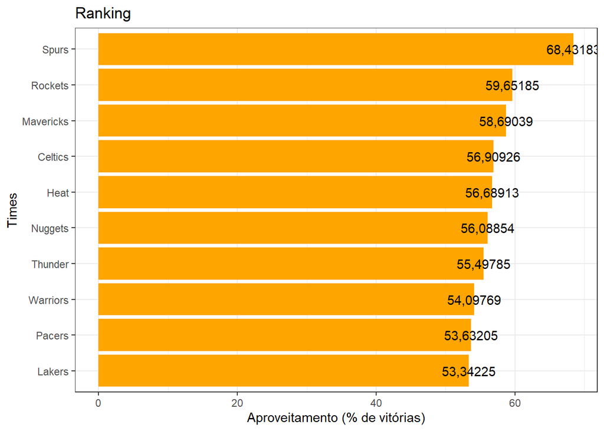

```r
ranking_total_top_10 %>%
 mutate(NICKNAME=fct_reorder(NICKNAME, per_W)) %>%
 ggplot(aes(x=NICKNAME, y=per_W)) +
    geom_bar(stat="identity", fill="orange") +
    geom_text(aes(label=format(per_W, nsmall=2, decimal=",")), color="black") +
    coord_flip() +
    ggtitle("Ranking") +
    xlab("Times") +
    ylab("Aproveitamento (% de vitórias)") +
    theme_bw()
```

### Gráfico temporal

```r
ranking$SEASON_ID = as.character(ranking$SEASON_ID)

season <- ranking %>%
    mutate(SEASON_ID=substr(SEASON_ID, 2,5)) %>%
    filter(G != 0) %>%
    inner_join(teams, by = "TEAM_ID") %>%
    group_by(NICKNAME, SEASON_ID, CONFERENCE) %>%
    summarise(per_W=(sum(W)/sum(G)) * 100) %>%
    arrange(SEASON_ID)
```

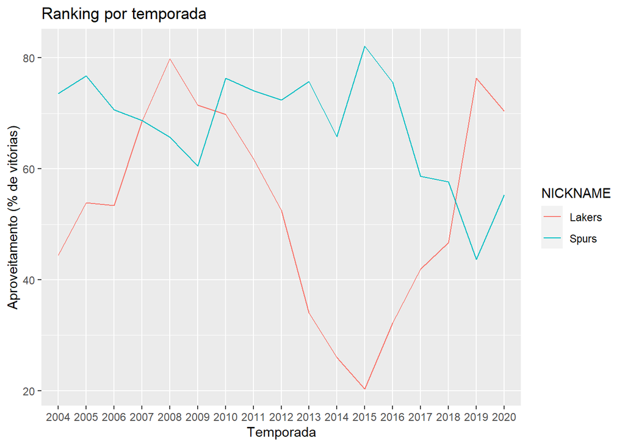

```r
season %>%
    filter(NICKNAME == "Spurs" | NICKNAME =="Lakers", SEASON_ID > 2003 ) %>%
    ggplot(aes(x = SEASON_ID, y = per_W, group = NICKNAME)) +
    geom_line(aes(color = NICKNAME)) +
    ggtitle("Ranking por temporada") +
    xlab("Temporada") +
    ylab("Aproveitamento (% de vitórias)")
```

## Tabela resumo - Ranking

```r
summary(ranking['G'])
```

```
##        G
##  Min.   : 0.00
##  1st Qu.:32.00
##  Median :67.00
##  Mean   :56.76
##  3rd Qu.:82.00
##  Max.   :82.00
```

```r
summary(ranking['W'])
```

```
##        W
##  Min.   : 0.00
##  1st Qu.:14.00
##  Median :28.00
##  Mean   :28.38
##  3rd Qu.:42.00
##  Max.   :73.00
```

```r
summary(ranking['W_PCT'])
```

```
##      W_PCT
##  Min.   :0.0000
##  1st Qu.:0.3680
##  Median :0.5000
##  Mean   :0.4925
##  3rd Qu.:0.6210
##  Max.   :1.0000
```

```r
summary(ranking['L'])
```

```
##        L
##  Min.   : 0.00
##  1st Qu.:14.00
##  Median :28.00
##  Mean   :28.38
##  3rd Qu.:41.00
##  Max.   :72.00
```

```r
G <-ranking %>%
      summarise(media = mean(G, na.rm = TRUE),
        dp = round( sd(G, na.rm = TRUE), 2), min = min(G, na.rm = TRUE),
        max = max(G, na.rm = TRUE),
        mediana = median(G, na.rm = TRUE),Q1=quantile(G, probs = 0.25),
                Q2=quantile(G, probs = 0.50),
                Q3=quantile(G, probs = 0.75))

W <-ranking %>%
      summarise(media = mean(W, na.rm = TRUE),
        dp = round( sd(W, na.rm = TRUE), 2), min = min(W, na.rm = TRUE),
        max = max(W, na.rm = TRUE),
        mediana = median(W, na.rm = TRUE),Q1=quantile(W, probs = 0.25),
                Q2=quantile(W, probs = 0.50),
                Q3=quantile(W, probs = 0.75))

L <-ranking %>%
      summarise(media = mean(L, na.rm = TRUE),
        dp = round( sd(L, na.rm = TRUE), 2), min = min(L, na.rm = TRUE),
        max = max(L, na.rm = TRUE),
        mediana = median(L, na.rm = TRUE),Q1=quantile(L, probs = 0.25),
                Q2=quantile(L, probs = 0.50),
                Q3=quantile(L, probs = 0.75))

G
```

```
## # A tibble: 1 x 8
##   media    dp   min   max mediana    Q1    Q2    Q3
##   <dbl> <dbl> <dbl> <dbl>   <dbl> <dbl> <dbl> <dbl>
## 1  56.8  28.7     0    82      67    32    67    82
```

```r
W
```

```
## # A tibble: 1 x 8
##   media    dp   min   max mediana    Q1    Q2    Q3
##   <dbl> <dbl> <dbl> <dbl>   <dbl> <dbl> <dbl> <dbl>
## 1  28.4  17.4     0    73      28    14    28    42
```

```r
L
```

```
## # A tibble: 1 x 8
##   media    dp   min   max mediana    Q1    Q2    Q3
##   <dbl> <dbl> <dbl> <dbl>   <dbl> <dbl> <dbl> <dbl>
## 1  28.4  17.4     0    72      28    14    28    41
```

## Maiores pontuadores

```r
base2<-inner_join(games_details,games,by="GAME_ID")

MaioresJog<-base2 %>%
  filter(SEASON>2003)%>%
  select(GAME_ID,TEAM_ID,PLAYER_NAME,PLAYER_ID,SEASON,PTS)%>%
  group_by(PLAYER_NAME)%>%
  summarise(Pontos=sum(PTS,na.rm=TRUE),
            Partidas=(GAME_ID=n()),
            MedPts=round(((Pontos/Partidas)),0))%>%
              arrange(desc(Pontos))

head(MaioresJog)
```

```
## # A tibble: 6 x 4
##   PLAYER_NAME     Pontos Partidas MedPts
##   <chr>            <dbl>    <int>  <dbl>
## 1 LeBron James     42412     1612     26
## 2 Kevin Durant     28891     1095     26
## 3 Carmelo Anthony  28507     1324     22
## 4 Dwyane Wade      26859     1284     21
## 5 James Harden     26238     1089     24
## 6 Dirk Nowitzki    26082     1290     20
```

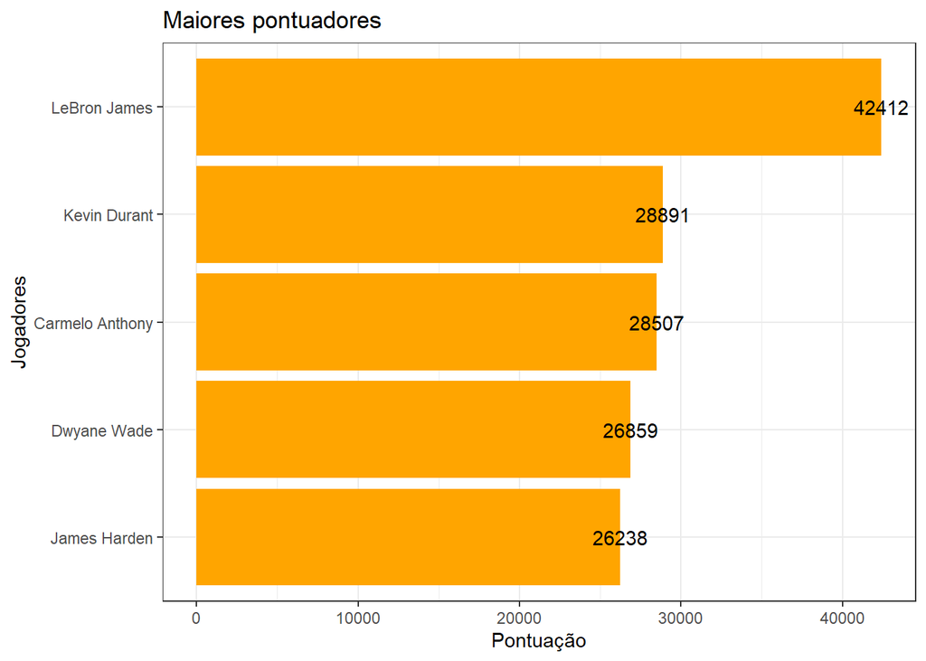

```r
head(MaioresJog,5) %>%
mutate(PLAYER_NAME=fct_reorder(PLAYER_NAME, Pontos)) %>%
    ggplot(aes(x=PLAYER_NAME, y=Pontos)) +
    geom_bar(stat="identity", fill="orange") +
    geom_text(aes(label=format(Pontos)),  color="black") +
    coord_flip() +
    ggtitle("Maiores pontuadores") +
    xlab("Jogadores") +
    ylab("Pontuação") +
    theme_bw()
```

## Melhores aproveitamentos por conferência

```r
base<-inner_join(ranking,teams,by="TEAM_ID")

MaioresVitWest<-base %>%
  select(CONFERENCE,TEAM,SEASON_ID,G,W_PCT,)%>%
    filter(G==82)%>%
    filter(CONFERENCE=="West") %>%
      group_by(CONFERENCE,TEAM,SEASON_ID,G,W_PCT)%>%
        summarise(max = max(W_PCT)) %>%
            arrange(desc(max))

head(MaioresVitWest)
```

```
## # A tibble: 6 x 6
## # Groups:   CONFERENCE, TEAM, SEASON_ID, G [6]
##   CONFERENCE TEAM         SEASON_ID     G W_PCT   max
##   <chr>      <chr>        <chr>     <dbl> <dbl> <dbl>
## 1 West       Golden State 22015        82 0.89  0.89
## 2 West       Dallas       22006        82 0.817 0.817
## 3 West       Golden State 22014        82 0.817 0.817
## 4 West       Golden State 22016        82 0.817 0.817
## 5 West       San Antonio  22015        82 0.817 0.817
## 6 West       Houston      22017        82 0.793 0.793
```

```r
MaioresVitEast<-base %>%
  select(CONFERENCE,TEAM,SEASON_ID,G,W_PCT,)%>%
    filter(G==82)%>%
    filter(CONFERENCE=="East") %>%
      group_by(CONFERENCE,TEAM,SEASON_ID,G,W_PCT)%>%
        summarise(max = max(W_PCT)) %>%
            arrange(desc(max))

head(MaioresVitEast)
```

```
## # A tibble: 6 x 6
## # Groups:   CONFERENCE, TEAM, SEASON_ID, G [6]
##   CONFERENCE TEAM      SEASON_ID     G W_PCT   max
##   <chr>      <chr>     <chr>     <dbl> <dbl> <dbl>
## 1 East       Boston    22007        82 0.805 0.805
## 2 East       Cleveland 22008        82 0.805 0.805
## 3 East       Miami     22012        82 0.805 0.805
## 4 East       Detroit   22005        82 0.78  0.78
## 5 East       Boston    22008        82 0.756 0.756
## 6 East       Chicago   22010        82 0.756 0.756
```

## Títulos por estado

```
## Scale on map varies by more than 10%, scale bar may be inaccurate
```

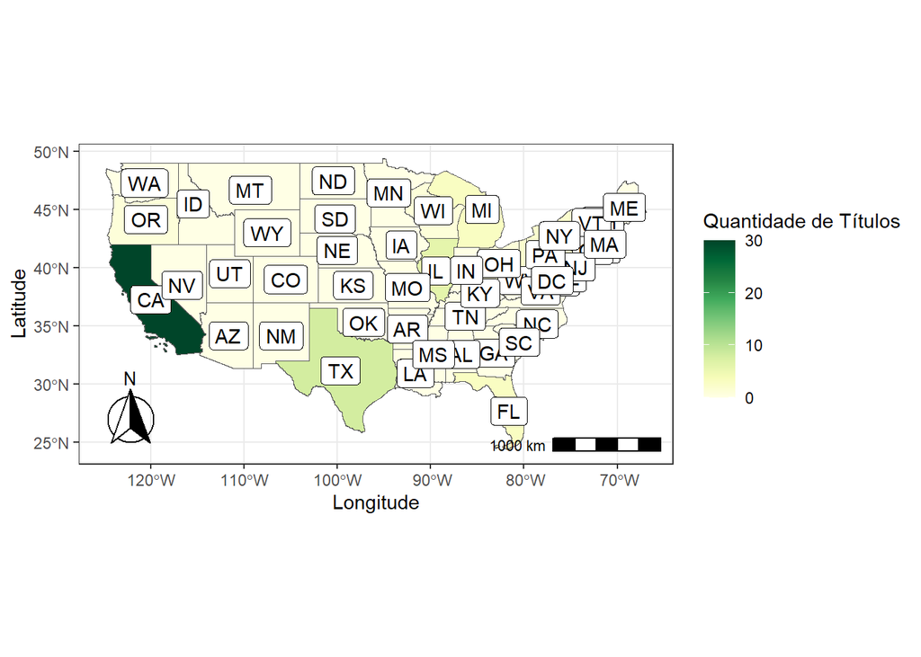

```r
mapa <- read_sf(usa_states,options="ENCODING=WINDOWS-1252")


est_tit <- read_delim(nba_titles, ";")
mapaClass <-left_join(mapa,est_tit)
mapaClass$Titulo[is.na(mapaClass$Titulo)] <- 0

ggplot(mapaClass)+ #Inserindo os dados
  geom_sf(aes(fill=Titulo), size = 0.05)+ #Criando um mapa para mostrar o número de habitantes para cada setor censitário [V002]
  scale_fill_gradientn(colours = brewer.pal(9,'YlGn'),na.value = "grey50")+ #Definindo uma nova paleta de cores
  geom_sf_label(aes(label=STUSPS),)+
  labs(x="Longitude",y="Latitude",fill="Quantidade de Títulos")+ #Definindo o título da escala de cores
  theme_minimal()+ #Definindo o tema do mapa
  annotation_north_arrow(style = north_arrow_fancy_orienteering)+
  annotation_scale(location="br")+
  theme_bw()
```

## Análise - Los Angeles Lakers

```r
G <-ranking %>%
  group_by(TEAM_ID) %>%
    filter(TEAM_ID==1610612747) %>%
      summarise(media = mean(G, na.rm = TRUE),
        dp = round( sd(G, na.rm = TRUE), 2), min = min(G, na.rm = TRUE),
        max = max(G, na.rm = TRUE),
        mediana = median(G, na.rm = TRUE),Q1=quantile(G, probs = 0.25),
                Q2=quantile(G, probs = 0.50),
                Q3=quantile(G, probs = 0.75))

W <-ranking %>%
  group_by(TEAM_ID) %>%
    filter(TEAM_ID==1610612747) %>%
      summarise(media = mean(W, na.rm = TRUE),
        dp = round( sd(W, na.rm = TRUE), 2), min = min(W, na.rm = TRUE),
        max = max(W, na.rm = TRUE),
        mediana = median(W, na.rm = TRUE),Q1=quantile(W, probs = 0.25),
                Q2=quantile(W, probs = 0.50),
                Q3=quantile(W, probs = 0.75))

L <-ranking %>%
  group_by(TEAM_ID) %>%
    filter(TEAM_ID==1610612747) %>%
      summarise(media = mean(L, na.rm = TRUE),
        dp = round( sd(L, na.rm = TRUE), 2), min = min(L, na.rm = TRUE),
        max = max(L, na.rm = TRUE),
        mediana = median(L, na.rm = TRUE), Q1=quantile(L, probs = 0.25),
                Q2=quantile(L, probs = 0.50),
                Q3=quantile(L, probs = 0.75))

G
```

```
## # A tibble: 1 x 9
##      TEAM_ID media    dp   min   max mediana    Q1    Q2    Q3
##        <dbl> <dbl> <dbl> <dbl> <dbl>   <dbl> <dbl> <dbl> <dbl>
## 1 1610612747  56.8  28.6     0    82      68    32    68    82
```

```r
W
```

```
## # A tibble: 1 x 9
##      TEAM_ID media    dp   min   max mediana    Q1    Q2    Q3
##        <dbl> <dbl> <dbl> <dbl> <dbl>   <dbl> <dbl> <dbl> <dbl>
## 1 1610612747  30.3  18.5     0    65      30    16    30    45
```

```r
L
```

```
## # A tibble: 1 x 9
##      TEAM_ID media    dp   min   max mediana    Q1    Q2    Q3
##        <dbl> <dbl> <dbl> <dbl> <dbl>   <dbl> <dbl> <dbl> <dbl>
## 1 1610612747  26.5  18.0     0    65      25    12    25    40
```

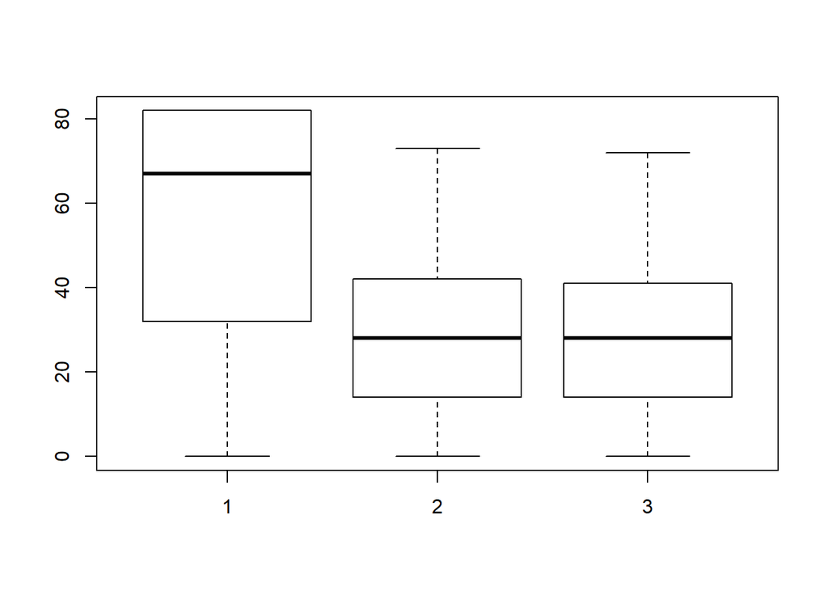

```r
boxplot(ranking$G,ranking$W,ranking$L)
```

### Lakers - Mandante

```r
lakers_home <-games %>%
  group_by(HOME_TEAM_ID) %>%
    filter(HOME_TEAM_ID==1610612747) %>%
      summarise(media_vitorias = mean(HOME_TEAM_WINS, na.rm = TRUE),
        dp = round( sd(HOME_TEAM_WINS, na.rm = TRUE), 2),
               media_pts_lakers = mean(PTS_home, na.rm = TRUE),
        dp_pts = round( sd(PTS_home, na.rm = TRUE), 2),
               media_pts_visitante = mean(PTS_away, na.rm = TRUE),
        dp_pts_vis = round( sd(PTS_away, na.rm = TRUE), 2))
lakers_home
```

```
## # A tibble: 1 x 7
##   HOME_TEAM_ID media_vitorias    dp media_pts_lakers dp_pts media_pts_visitante
##          <dbl>          <dbl> <dbl>            <dbl>  <dbl>               <dbl>
## 1   1610612747          0.602  0.49             104.   12.4                101.
## # ... with 1 more variable: dp_pts_vis <dbl>
```

### Lakers - Visitante

```r
lakers_away <-games %>%
  group_by(VISITOR_TEAM_ID) %>%
    filter(VISITOR_TEAM_ID==1610612747) %>%
      summarise(media_vitorias_mandante = 1-mean(HOME_TEAM_WINS, na.rm = TRUE),
        dp = round( sd(HOME_TEAM_WINS, na.rm = TRUE), 2),
               media_pts_lakers = mean(PTS_away, na.rm = TRUE),
        dp_pts_lakers = round( sd(PTS_home, na.rm = TRUE), 2),
               media_pts_mandante = mean(PTS_home, na.rm = TRUE),
        dp_pts_mandante = round( sd(PTS_away, na.rm = TRUE), 2))
lakers_away
```

```
## # A tibble: 1 x 7
##   VISITOR_TEAM_ID media_vitorias_mandante    dp media_pts_lakers dp_pts_lakers
##             <dbl>                   <dbl> <dbl>            <dbl>         <dbl>
## 1      1610612747                   0.442   0.5             102.          12.4
## # ... with 2 more variables: media_pts_mandante <dbl>, dp_pts_mandante <dbl>
```

### Times mais derrotados pelos lakers em Los Angeles

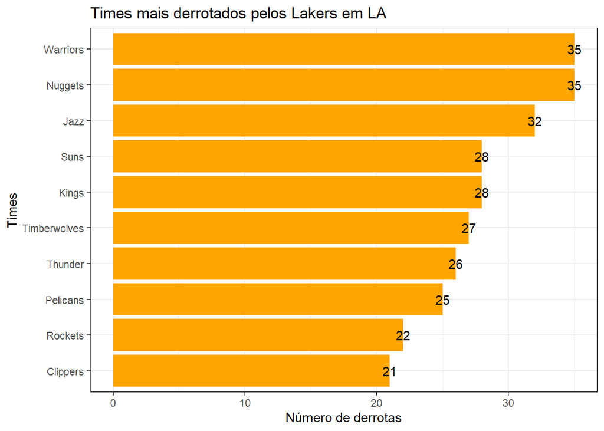

```r
lakers_home <-games %>%
  group_by(HOME_TEAM_ID) %>%
    select(HOME_TEAM_ID, TEAM_ID = VISITOR_TEAM_ID, HOME_TEAM_WINS) %>%
        filter(HOME_TEAM_ID==1610612747)


lakers_home_join <- inner_join(lakers_home, teams, by="TEAM_ID")
derrotas <- lakers_home_join %>%
                group_by(NICKNAME) %>%
                    summarise(Derrotas = sum(HOME_TEAM_WINS)) %>%
                        arrange(desc(Derrotas)) %>% slice(1:10)


derrotas %>%
    mutate(NICKNAME=fct_reorder(NICKNAME, Derrotas)) %>%
    ggplot(aes(x=NICKNAME, y=Derrotas)) +
    geom_bar(stat="identity", fill="orange") +
    geom_text(aes(label=format(Derrotas)),  color="black") +
    coord_flip() +
    ggtitle("Times mais derrotados pelos Lakers em LA") +
    xlab("Times") +
    ylab("Número de derrotas") +
    theme_bw()
```

### Times que mais derrotaram os Lakers em LA

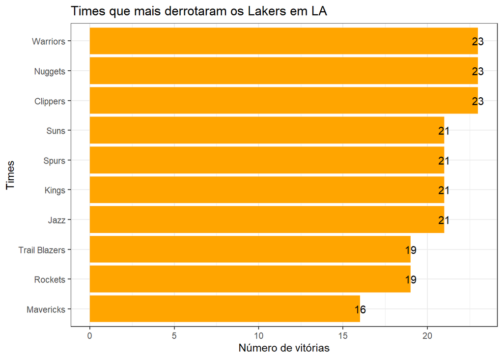

```r
lakers_home <-games %>%
  group_by(HOME_TEAM_ID) %>%
    select(HOME_TEAM_ID, TEAM_ID = VISITOR_TEAM_ID, HOME_TEAM_WINS) %>%
        filter(HOME_TEAM_ID==1610612747)


lakers_home_join <- inner_join(lakers_home, teams, by="TEAM_ID")
derrotas <- lakers_home_join %>%
                filter(HOME_TEAM_WINS==0) %>%
                    mutate(AWAY_TEAM_WINS = 1) %>%
                       select(HOME_TEAM_ID, NICKNAME, AWAY_TEAM_WINS) %>%
                        group_by(NICKNAME) %>%
                         summarise(Derrotas = sum(AWAY_TEAM_WINS)) %>%
                            arrange(desc(Derrotas)) %>% slice(1:10)

derrotas %>%
    mutate(NICKNAME=fct_reorder(NICKNAME, Derrotas)) %>%
    ggplot(aes(x=NICKNAME, y=Derrotas)) +
    geom_bar(stat="identity", fill="orange") +
    geom_text(aes(label=format(Derrotas)),  color="black") +
    coord_flip() +
    ggtitle("Times que mais derrotaram os Lakers em LA") +
    xlab("Times") +
    ylab("Número de vitórias") +
    theme_bw()
```

### Jogadores que mais vezes compuseram o elenco dos Lakers

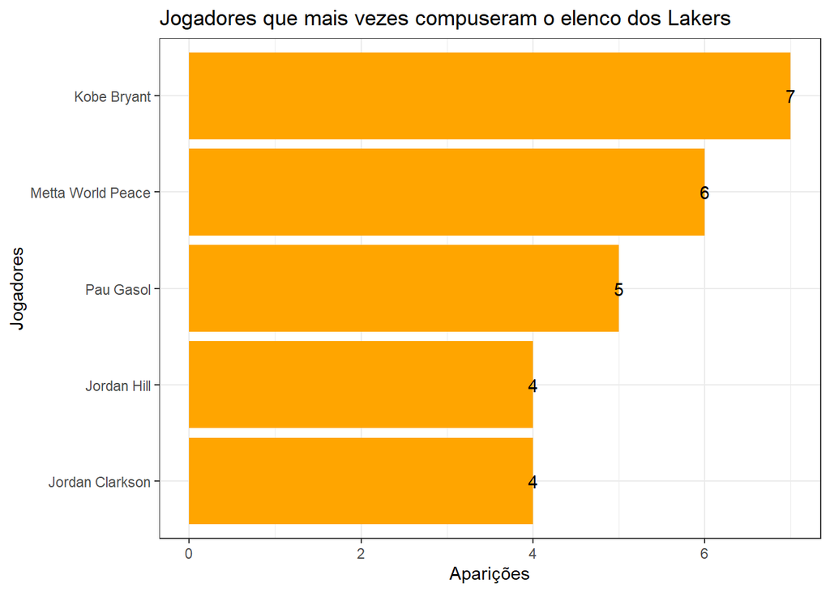

```r
lakers_players <-players %>%
                    filter(TEAM_ID==1610612747) %>%
                        mutate(APARICAO = 1) %>%
                            group_by(PLAYER_NAME) %>%
                                summarise(APARICOES = sum(APARICAO)) %>%
                                    arrange(desc(APARICOES)) %>% slice(1:5)
lakers_players %>%
mutate(PLAYER_NAME=fct_reorder(PLAYER_NAME, APARICOES)) %>%
    ggplot(aes(x=PLAYER_NAME, y=APARICOES)) +
    geom_bar(stat="identity", fill="orange") +
    geom_text(aes(label=format(APARICOES)),  color="black") +
    coord_flip() +
    ggtitle("Jogadores que mais vezes compuseram o elenco dos Lakers") +
    xlab("Jogadores") +
    ylab("Aparições") +
    theme_bw()
```

## Análise do Jogador LeBron James

```r
lebron_df <-games_details %>%
                inner_join(games,by="GAME_ID") %>%
                filter(SEASON>2003)%>%
                    filter(PLAYER_ID==2544) %>%
                        mutate(APARICAO = 1) %>%
                            group_by(PLAYER_NAME, TEAM_CITY) %>%
                                summarise(APARICOES = sum(APARICAO)) %>%
                                    arrange(desc(APARICOES))
```

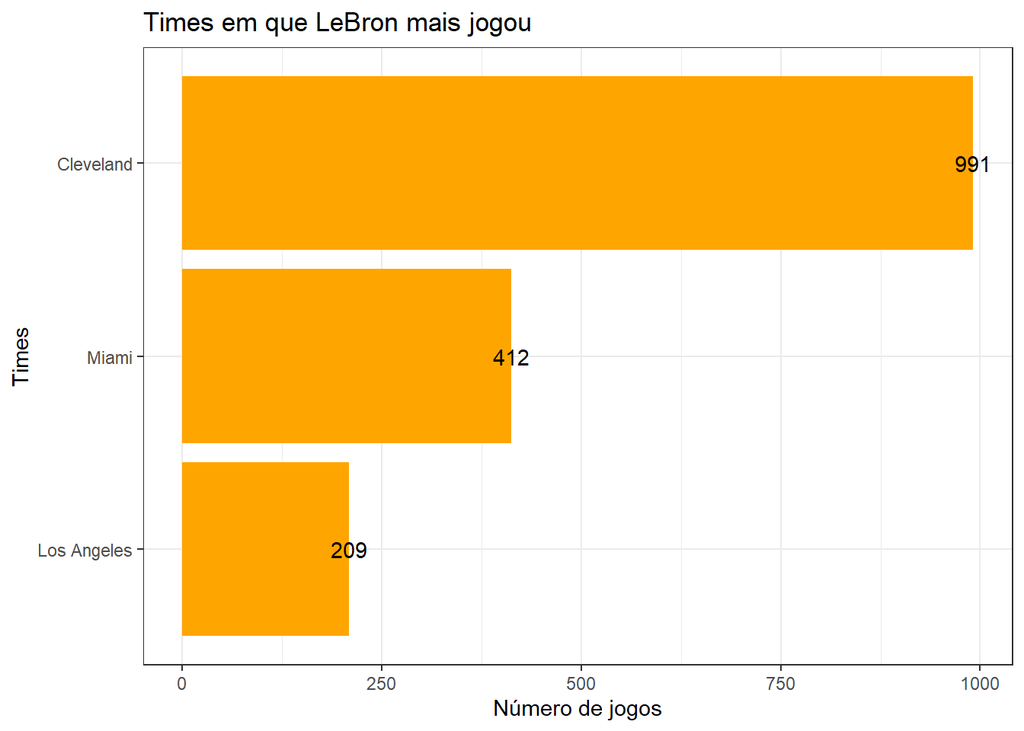

```r
lebron_df %>%
mutate(TEAM_CITY=fct_reorder(TEAM_CITY, APARICOES)) %>%
    ggplot(aes(x=TEAM_CITY, y=APARICOES)) +
    geom_bar(stat="identity", fill="orange") +
    geom_text(aes(label=format(APARICOES)),  color="black") +
    coord_flip() +
    ggtitle("Times em que LeBron mais jogou") +
    xlab("Times") +
    ylab("Número de jogos") +
    theme_bw()
```

```r
lebron_df <-games_details %>%
              inner_join(games,by="GAME_ID") %>%
                mutate(APARICOES = 1) %>%
                filter(SEASON>2003)%>%
                    filter(PLAYER_ID==2544) %>%
                            group_by(PLAYER_NAME) %>%
                                summarise(GAMES = sum(APARICOES),PTS_MADE = sum(PTS, na.rm = TRUE),
                                          MAX_PTS = max(PTS, na.rm = TRUE),
                                          MIN_PTS=min(PTS, na.rm = TRUE),
                                             MEAN_PTS=round(mean(PTS, na.rm = TRUE),2),
                                                FG_PCT = sum(FGM, na.rm = TRUE)/sum(FGA, na.rm = TRUE),
                                                 FG3_PCT = sum(FG3M, na.rm = TRUE)/sum(FG3A, na.rm = TRUE)) %>%
                                    arrange(desc(PTS_MADE))
lebron_df
```

```
## # A tibble: 1 x 8
##   PLAYER_NAME  GAMES PTS_MADE MAX_PTS MIN_PTS MEAN_PTS FG_PCT FG3_PCT
##   <chr>        <dbl>    <dbl>   <dbl>   <dbl>    <dbl>  <dbl>   <dbl>
## 1 LeBron James  1612    42412      61       1     27.1  0.506   0.345
```

# Trabalho Final

## Jogo em casa influêcia?

```r
games %>%
    select(PTS_home, PTS_away) %>%
    mutate(home_win = factor(if_else(PTS_home > PTS_away, "Sede", "Visitante"))) %>%
    summarytools::freq()
```

```
## Variable(s) ignored: PTS_home, PTS_away
```

```
## Frequencies
## games$home_win
## Type: Factor
##
##                    Freq   % Valid   % Valid Cum.   % Total   % Total Cum.
## --------------- ------- --------- -------------- --------- --------------
##            Sede   14269     59.22          59.22     58.97          58.97
##       Visitante    9827     40.78         100.00     40.62          99.59
##            <NA>      99                               0.41         100.00
##           Total   24195    100.00         100.00    100.00         100.00
```

```r
Table <- matrix(c(59.22,40.78,40.78,59.22), 2, 2, byrow = TRUE)
dimnames(Table) <- list(rows = c("Ganhou", "Perdeu"), columns = c("Casa", "Fora"))
Table
```

```
##         columns
## rows      Casa  Fora
##   Ganhou 59.22 40.78
##   Perdeu 40.78 59.22
```

```r
Test <- chisq.test(Table)
Test
```

```
##
##  Pearson's Chi-squared test with Yates' continuity correction
##
## data:  Table
## X-squared = 6.0831, df = 1, p-value = 0.01365
```

```r
Test$expected
```

```
##         columns
## rows     Casa Fora
##   Ganhou   50   50
##   Perdeu   50   50
```

H0 = Valores independentes

H1 = Valores dependentes

p-valor < 0,05 rejeita-se hipótese nula, ou seja, Jogar em casa influencia na vitória

### Comparação das demais estatísticas

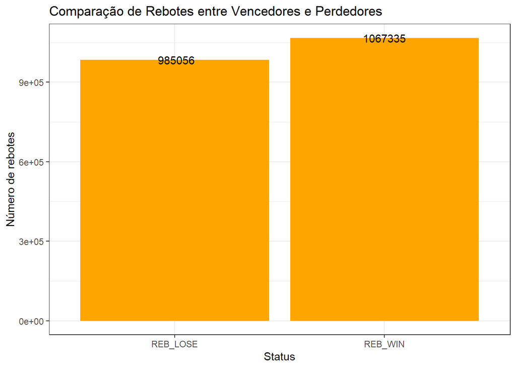

```r
stats_chart <- games %>%
                select(HOME_TEAM_WINS, PTS_home, FG_PCT_home, FT_PCT_home, FG3_PCT_home, AST_home, REB_home,
                       PTS_away, FG_PCT_away, FT_PCT_away, FG3_PCT_away, AST_away, REB_away) %>%
                mutate(PTS_WIN = if_else(HOME_TEAM_WINS == 1, PTS_home, PTS_away)) %>%
                mutate(PTS_LOSE = if_else(HOME_TEAM_WINS == 0, PTS_home, PTS_away)) %>%
                mutate(FG_PCT_WIN = if_else(HOME_TEAM_WINS == 1, FG_PCT_home, FG_PCT_away)) %>%
                mutate(FG_PCT_LOSE = if_else(HOME_TEAM_WINS == 0, FG_PCT_home, FG_PCT_away)) %>%
                mutate(FT_PCT_WIN = if_else(HOME_TEAM_WINS == 1, FT_PCT_home, FT_PCT_away)) %>%
                mutate(FT_PCT_LOSE = if_else(HOME_TEAM_WINS == 0, FT_PCT_home, FT_PCT_away)) %>%
                mutate(FG3_PCT_WIN = if_else(HOME_TEAM_WINS == 1, FG3_PCT_home, FG3_PCT_away)) %>%
                mutate(FG3_PCT_LOSE = if_else(HOME_TEAM_WINS == 0, FG3_PCT_home, FG3_PCT_away)) %>%
                mutate(AST_WIN = if_else(HOME_TEAM_WINS == 1, AST_home, AST_away)) %>%
                mutate(AST_LOSE = if_else(HOME_TEAM_WINS == 0, AST_home, AST_away)) %>%
                mutate(REB_WIN = if_else(HOME_TEAM_WINS == 1, REB_home, REB_away)) %>%
                mutate(REB_LOSE = if_else(HOME_TEAM_WINS == 0, REB_home, REB_away)) %>%
                select(HOME_TEAM_WINS, PTS_WIN,PTS_LOSE,FG_PCT_WIN,FG_PCT_LOSE,FT_PCT_WIN,FT_PCT_LOSE,FG3_PCT_WIN,
                      FG3_PCT_LOSE,AST_WIN,AST_LOSE,REB_WIN,REB_LOSE)


chart_reb_win <- stats_chart %>% select(Count = REB_WIN) %>% filter(Count!='NA') %>% mutate(Label = 'REB_WIN')
chart_reb_lose <- stats_chart %>% select(Count = REB_LOSE) %>% filter(Count!='NA') %>% mutate(Label = 'REB_LOSE')
reb_chart <- rbind(chart_reb_win, chart_reb_lose)

#reb_chart

count_chart <- reb_chart %>%
                group_by(Label) %>%
                  summarise(count = sum(Count))
count_chart %>%
ggplot(aes(x=Label, y=count)) +
    geom_bar(stat="identity", fill="orange") +
    geom_text(aes(label=format(count)),  color="black") +
    ggtitle("Comparação de Rebotes entre Vencedores e Perdedores") +
    xlab("Status") +
    ylab("Número de rebotes") +
    theme_bw()
```

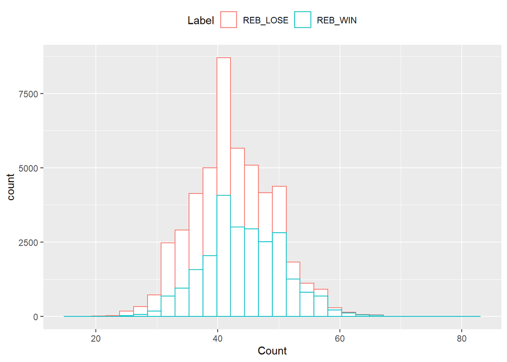

```r
options(repr.plot.width = 6, repr.plot.height = 4)
ggplot(reb_chart, aes(x=Count, color=Label)) +
geom_histogram(fill="white", bins=30) + theme(legend.position="top")
```

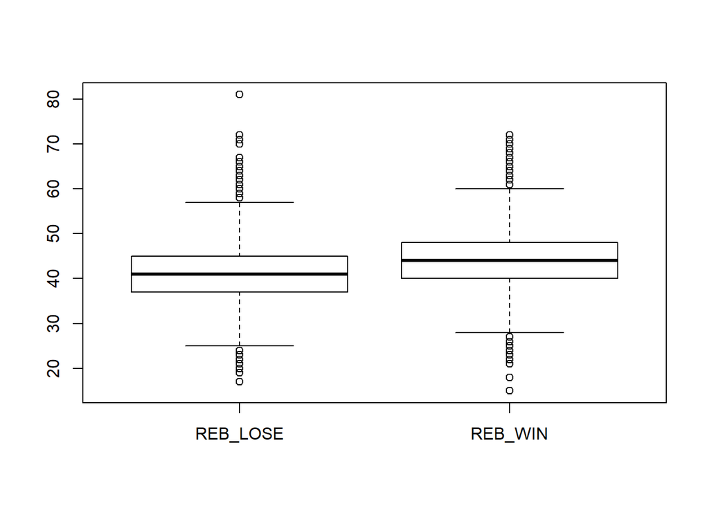

```r
boxplot(chart_reb_lose$Count,chart_reb_win$Count,names=c("REB_LOSE","REB_WIN"))
```

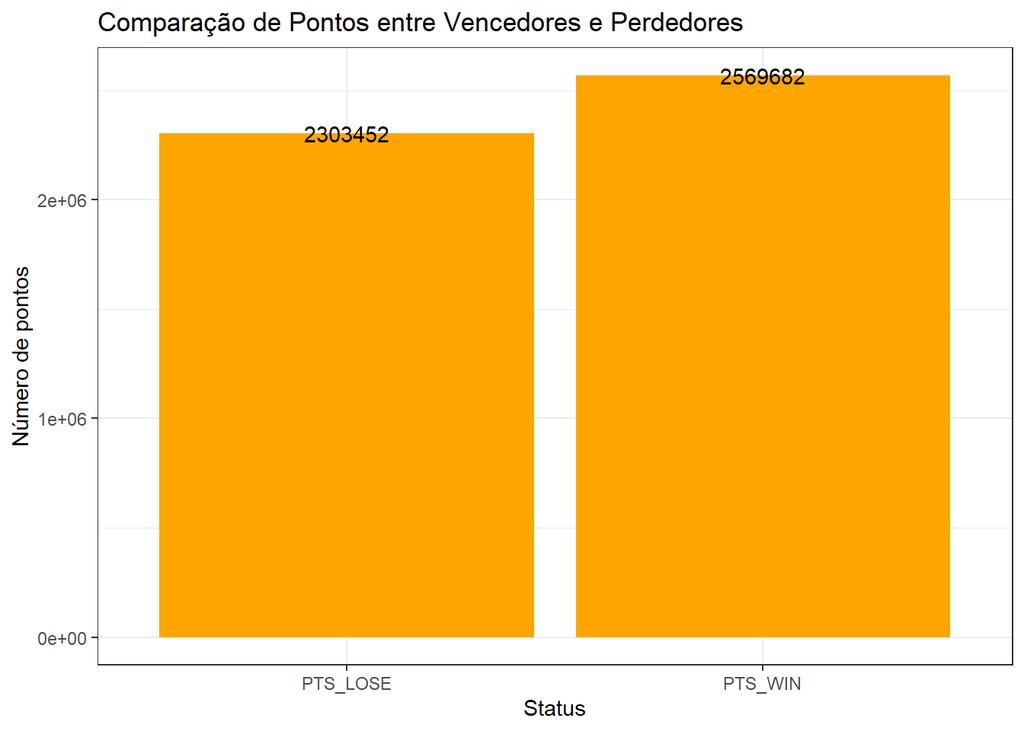

```r
chart_pts_win <- stats_chart %>% select(Count = PTS_WIN) %>% filter(Count!='NA') %>% mutate(Label = 'PTS_WIN')
chart_pts_lose <- stats_chart %>% select(Count = PTS_LOSE) %>% filter(Count!='NA') %>% mutate(Label = 'PTS_LOSE')

pts_chart <- rbind(chart_pts_win, chart_pts_lose)
#reb_chart

count_chart <- pts_chart %>% group_by(Label) %>% summarise(count = sum(Count))
count_chart %>%
ggplot(aes(x=Label, y=count)) +
    geom_bar(stat="identity", fill="orange") +
    geom_text(aes(label=format(count)),  color="black") +
    ggtitle("Comparação de Pontos entre Vencedores e Perdedores") +
    xlab("Status") +
    ylab("Número de pontos") +
    theme_bw()
```

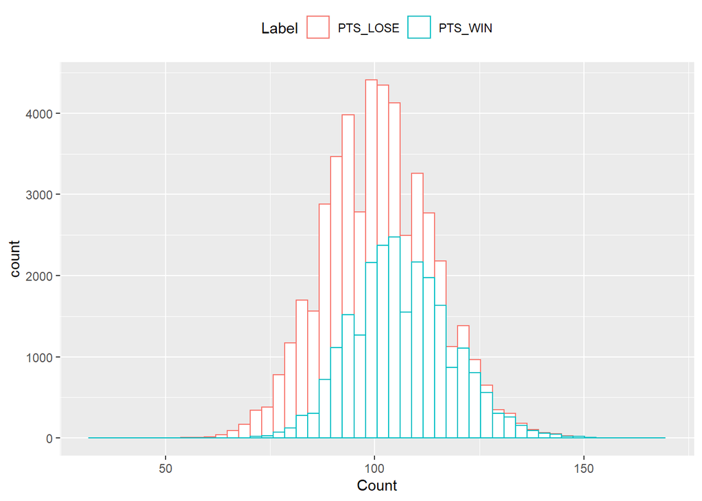

```r
options(repr.plot.width = 6, repr.plot.height = 4)
ggplot(pts_chart, aes(x=Count, color=Label)) +
geom_histogram(fill="white", bins=50) + theme(legend.position="top")
```

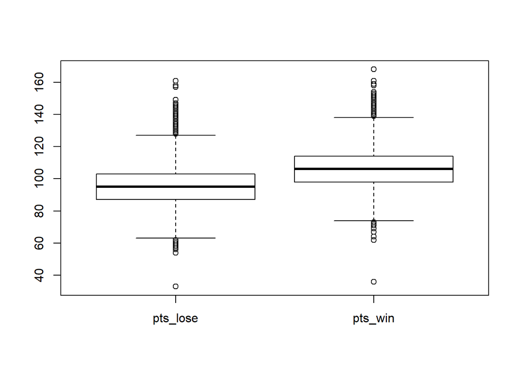

```r
boxplot(chart_pts_lose$Count, chart_pts_win$Count,names=c("pts_lose","pts_win"))
```

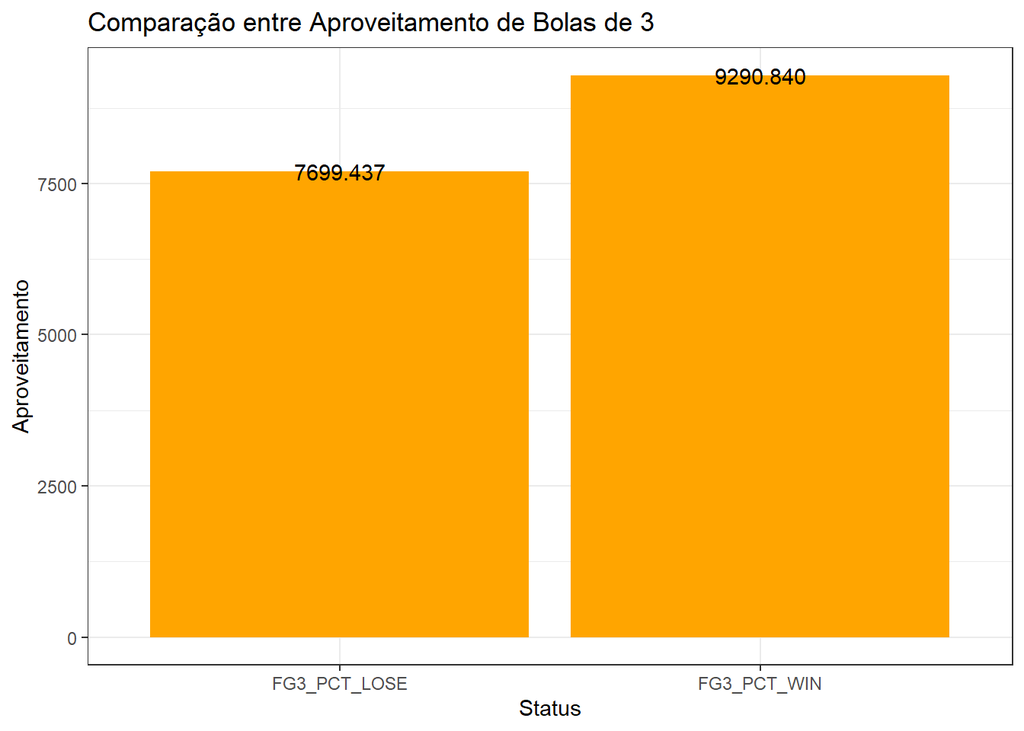

```r
chart_pts_win <- stats_chart %>% select(Count = FG3_PCT_WIN) %>% filter(Count!='NA') %>% mutate(Label = 'FG3_PCT_WIN')
chart_pts_lose <- stats_chart %>% select(Count = FG3_PCT_LOSE) %>% filter(Count!='NA') %>% mutate(Label = 'FG3_PCT_LOSE')

pts_chart <- rbind(chart_pts_win, chart_pts_lose)
#reb_chart

count_chart <- pts_chart %>% group_by(Label) %>% summarise(count = sum(Count))
count_chart %>%
ggplot(aes(x=Label, y=count)) +
    geom_bar(stat="identity", fill="orange") +
    geom_text(aes(label=format(count)),  color="black") +
    ggtitle("Comparação entre Aproveitamento de Bolas de 3") +
    xlab("Status") +
    ylab("Aproveitamento") +
    theme_bw()
```

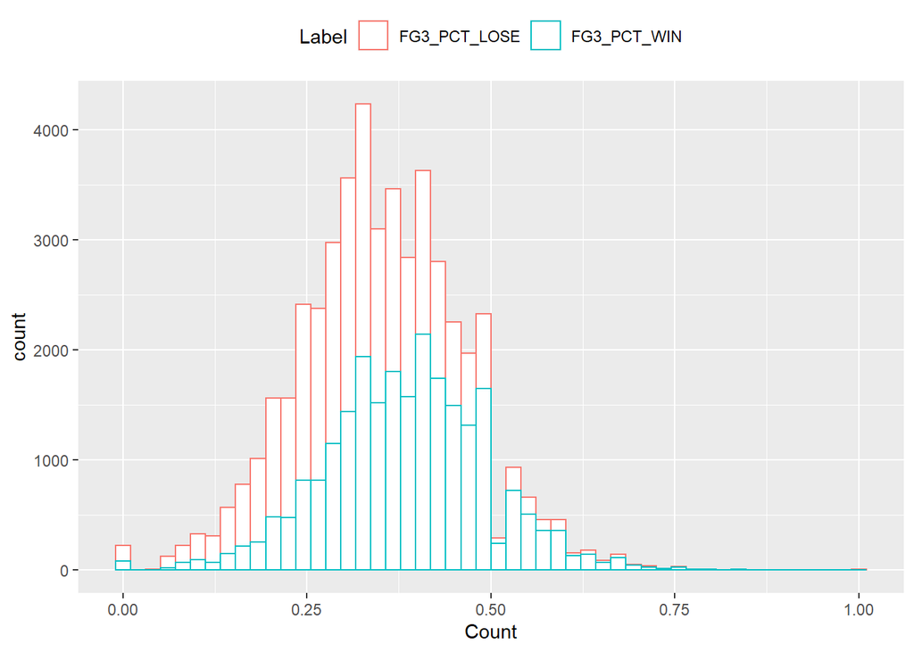

```r
options(repr.plot.width = 6, repr.plot.height = 4)
ggplot(pts_chart, aes(x=Count, color=Label)) +
geom_histogram(fill="white", bins=50) + theme(legend.position="top")
```

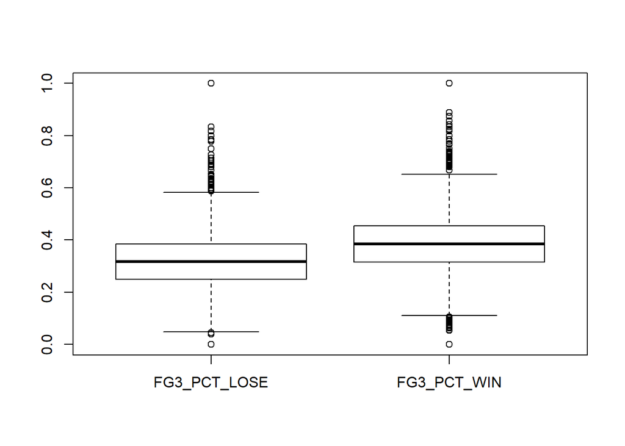

```r
boxplot(chart_pts_lose$Count, chart_pts_win$Count,names=c("FG3_PCT_LOSE","FG3_PCT_WIN"))
```

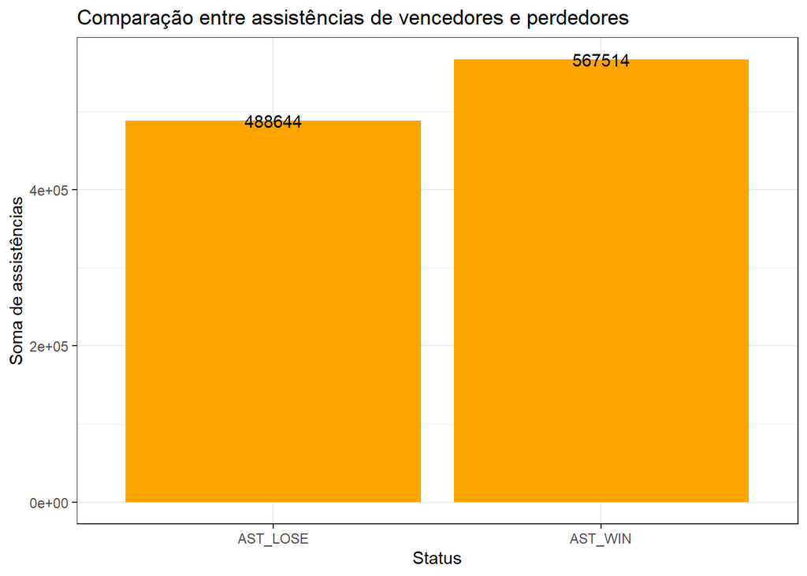

```r
chart_pts_win <- stats_chart %>% select(Count = AST_WIN) %>% filter(Count!='NA') %>% mutate(Label = 'AST_WIN')
chart_pts_lose <- stats_chart %>% select(Count = AST_LOSE) %>% filter(Count!='NA') %>% mutate(Label = 'AST_LOSE')

pts_chart <- rbind(chart_pts_win, chart_pts_lose)
#reb_chart

count_chart <- pts_chart %>% group_by(Label) %>% summarise(count = sum(Count))
count_chart %>%
ggplot(aes(x=Label, y=count)) +
    geom_bar(stat="identity", fill="orange") +
    geom_text(aes(label=format(count)),  color="black") +
    ggtitle("Comparação entre assistências de vencedores e perdedores") +
    xlab("Status") +
    ylab("Soma de assistências") +
    theme_bw()
```

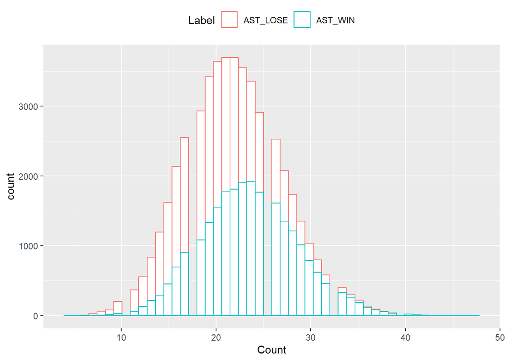

```r
options(repr.plot.width = 6, repr.plot.height = 4)
ggplot(pts_chart, aes(x=Count, color=Label)) +
geom_histogram(fill="white", bins=50) + theme(legend.position="top")
```

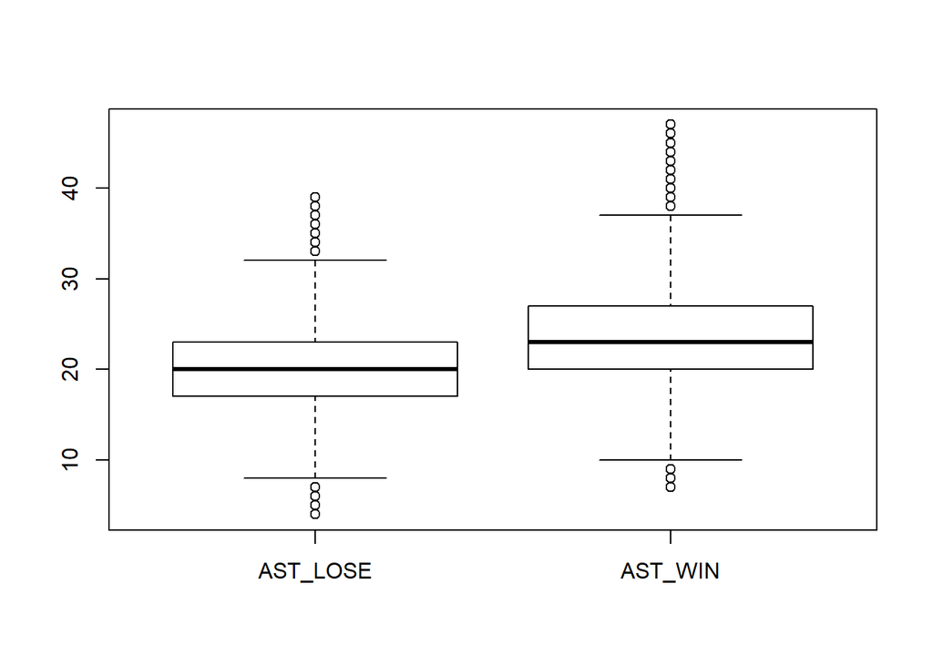

```r
boxplot(chart_pts_lose$Count, chart_pts_win$Count,names=c("AST_LOSE","AST_WIN"))
```

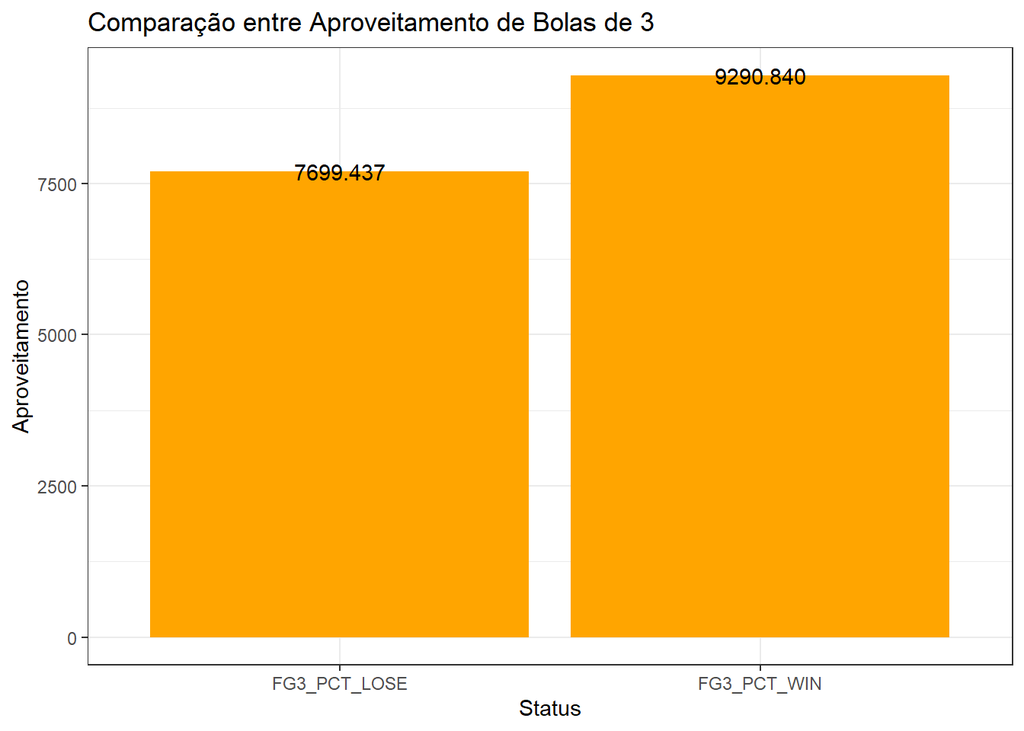

```r
chart_pts_win <- stats_chart %>% select(Count = FG3_PCT_WIN) %>% filter(Count!='NA') %>% mutate(Label = 'FG3_PCT_WIN')
chart_pts_lose <- stats_chart %>% select(Count = FG3_PCT_LOSE) %>% filter(Count!='NA') %>% mutate(Label = 'FG3_PCT_LOSE')

pts_chart <- rbind(chart_pts_win, chart_pts_lose)
#reb_chart

count_chart <- pts_chart %>% group_by(Label) %>% summarise(count = sum(Count))
count_chart %>%
ggplot(aes(x=Label, y=count)) +
    geom_bar(stat="identity", fill="orange") +
    geom_text(aes(label=format(count)),  color="black") +
    ggtitle("Comparação entre Aproveitamento de Bolas de 3") +
    xlab("Status") +
    ylab("Aproveitamento") +
    theme_bw()
```

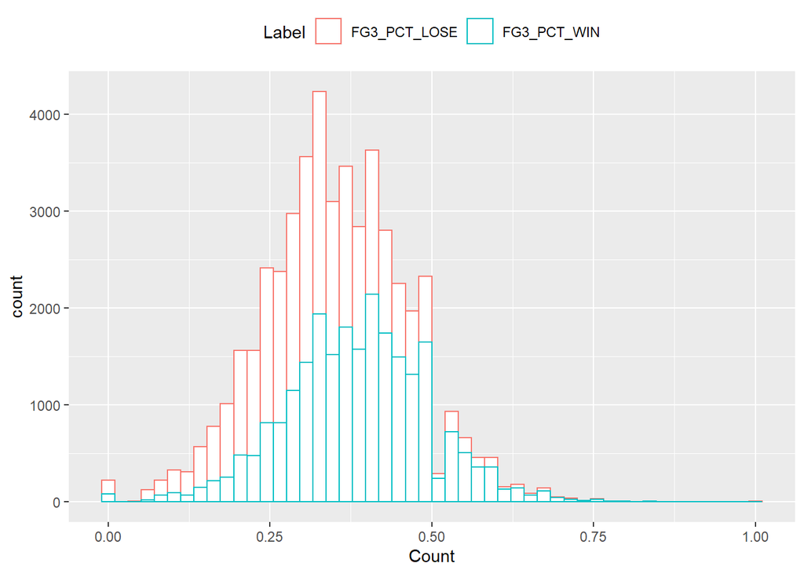

```r
options(repr.plot.width = 6, repr.plot.height = 4)
ggplot(pts_chart, aes(x=Count, color=Label)) +
geom_histogram(fill="white", bins=50) + theme(legend.position="top")
```

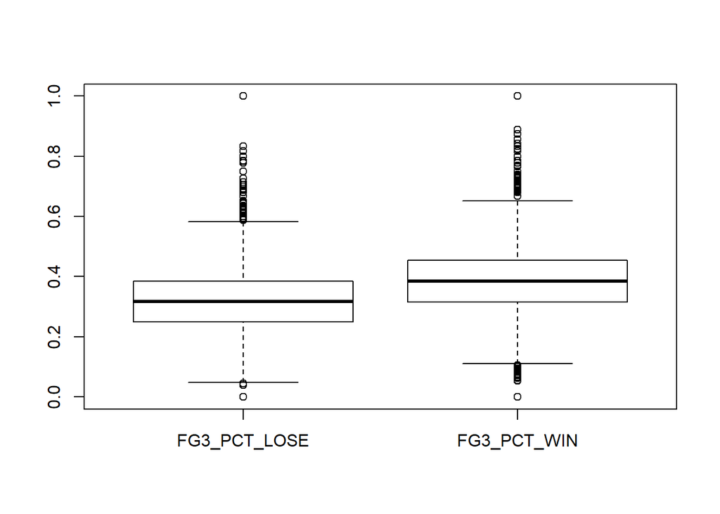

```r
boxplot(chart_pts_lose$Count, chart_pts_win$Count,names=c("FG3_PCT_LOSE","FG3_PCT_WIN"))
```

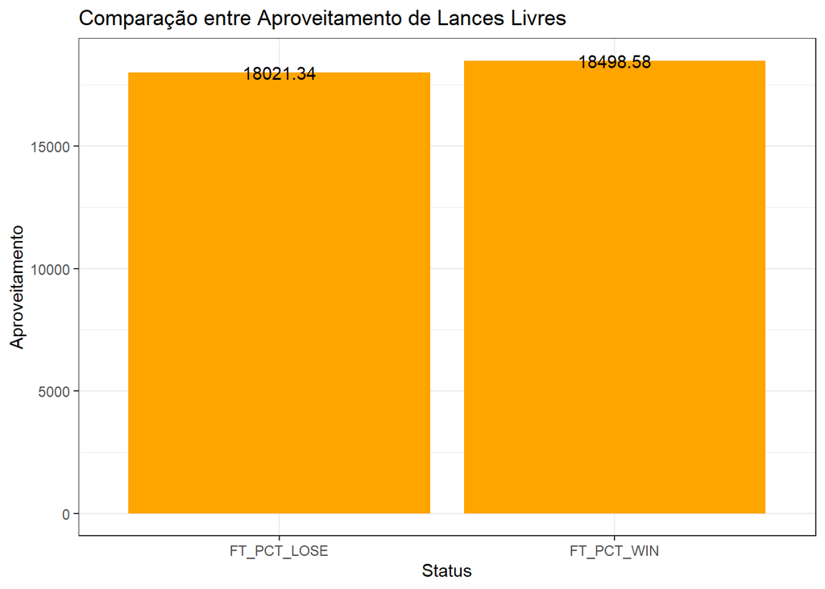

```r
chart_pts_win <- stats_chart %>% select(Count = FT_PCT_WIN) %>% filter(Count!='NA') %>% mutate(Label = 'FT_PCT_WIN')
chart_pts_lose <- stats_chart %>% select(Count = FT_PCT_LOSE) %>% filter(Count!='NA') %>% mutate(Label = 'FT_PCT_LOSE')

pts_chart <- rbind(chart_pts_win, chart_pts_lose)
#reb_chart

count_chart <- pts_chart %>% group_by(Label) %>% summarise(count = sum(Count))
count_chart %>%
ggplot(aes(x=Label, y=count)) +
    geom_bar(stat="identity", fill="orange") +
    geom_text(aes(label=format(count)),  color="black") +
    ggtitle("Comparação entre Aproveitamento de Lances Livres") +
    xlab("Status") +
    ylab("Aproveitamento") +
    theme_bw()
```

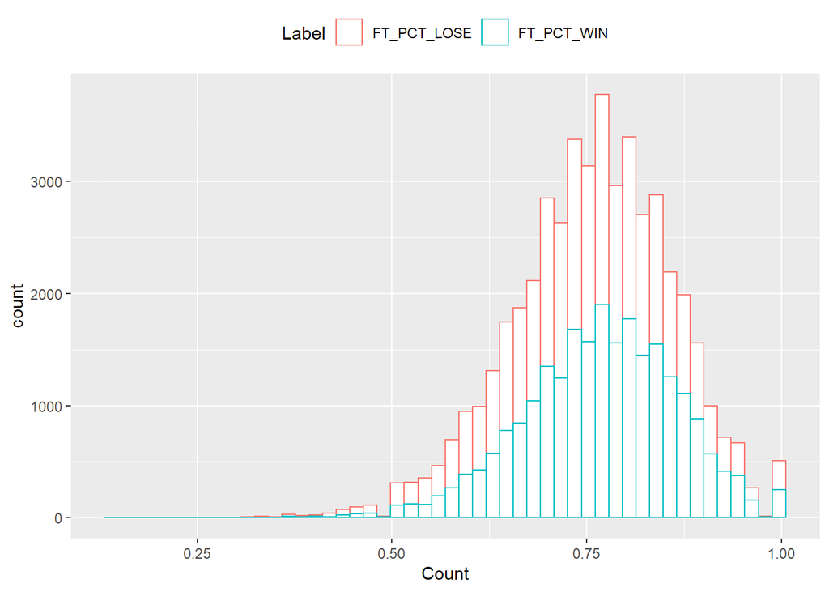

```r
options(repr.plot.width = 6, repr.plot.height = 4)
ggplot(pts_chart, aes(x=Count, color=Label)) +
geom_histogram(fill="white", bins=50) + theme(legend.position="top")
```

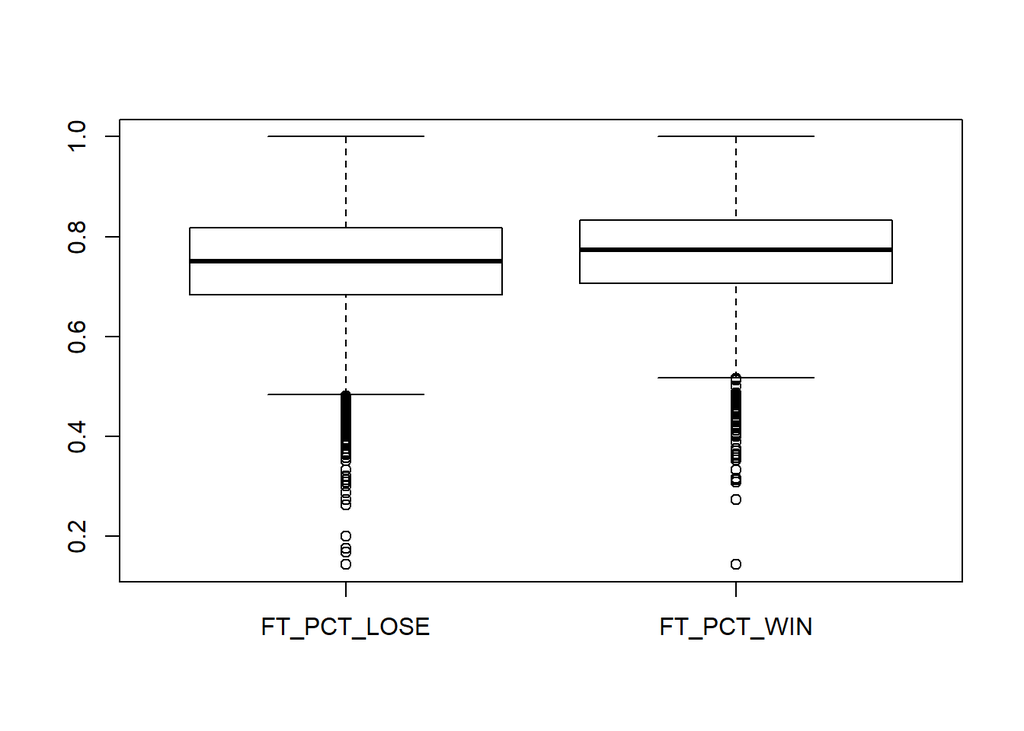

```r
boxplot(chart_pts_lose$Count, chart_pts_win$Count,names=c("FT_PCT_LOSE","FT_PCT_WIN"))
```

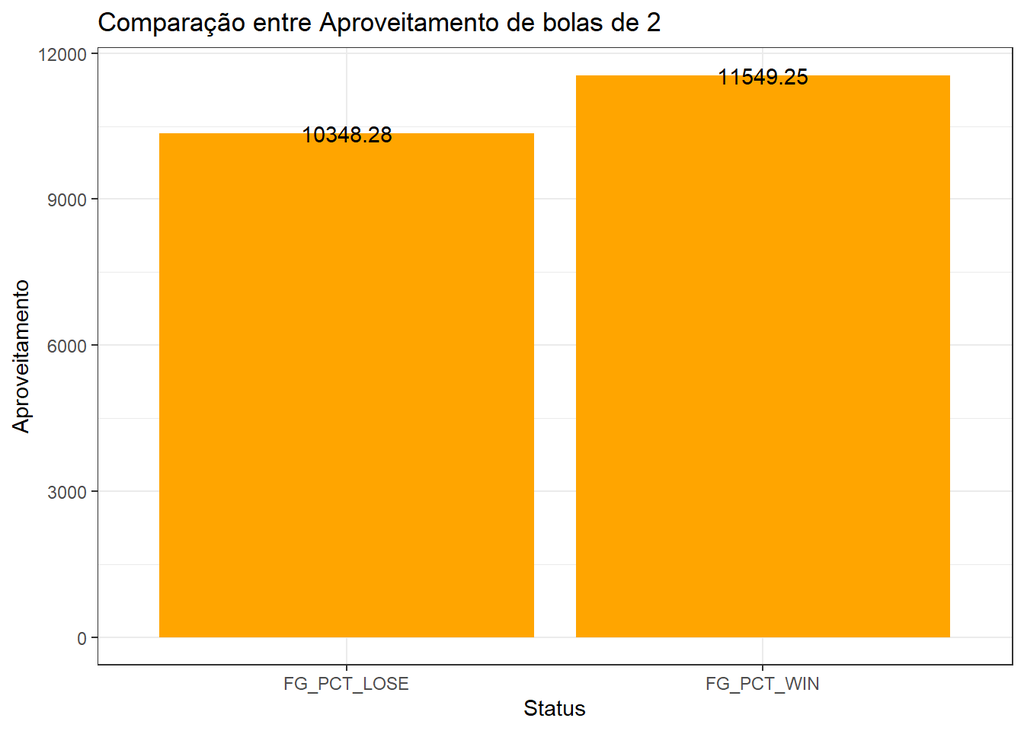

```r
chart_pts_win <- stats_chart %>% select(Count = FG_PCT_WIN) %>% filter(Count!='NA') %>% mutate(Label = 'FG_PCT_WIN')
chart_pts_lose <- stats_chart %>% select(Count = FG_PCT_LOSE) %>% filter(Count!='NA') %>% mutate(Label = 'FG_PCT_LOSE')

pts_chart <- rbind(chart_pts_win, chart_pts_lose)
#reb_chart

count_chart <- pts_chart %>% group_by(Label) %>% summarise(count = sum(Count))
count_chart %>%
ggplot(aes(x=Label, y=count)) +
    geom_bar(stat="identity", fill="orange") +
    geom_text(aes(label=format(count)),  color="black") +
    ggtitle("Comparação entre Aproveitamento de bolas de 2") +
    xlab("Status") +
    ylab("Aproveitamento") +
    theme_bw()
```

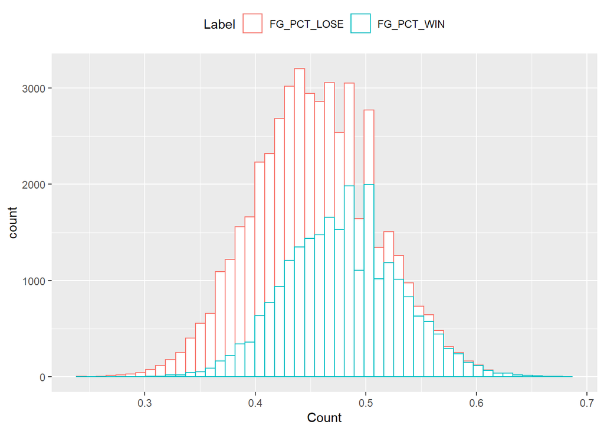

```r
options(repr.plot.width = 6, repr.plot.height = 4)
ggplot(pts_chart, aes(x=Count, color=Label)) +
geom_histogram(fill="white", bins=50) + theme(legend.position="top")
```

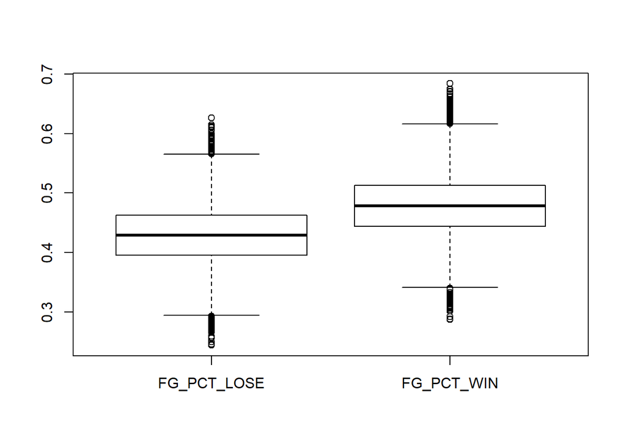

```r
boxplot(chart_pts_lose$Count, chart_pts_win$Count,names=c("FG_PCT_LOSE","FG_PCT_WIN"))
```